# Hierarchical model (F-model) for allele frequencies

Fiona Moss

## Summary:

The following are conclusions from the analysis:

1. $F_{ST}$ Bayesian agrees with $F_{ST}$ Hudson in terms of ranking.
2. There was nothing exceptional in $F_{ST}$ of 16,103 loci in ddrad data.
3. Among the three focal scaffolds that were presented in the paper, only scaffold 299 showed improbable/exceptional differentiation.

## Analysis of Data:

In the previous analysis, we did not have a model for variation among loci since we used Hudson’s $F_{ST}$ without random effects (fixed effects). We also did not add additional uncertainty to $F_{ST}$. In order to know the genetics of the model, we need to link all the allele frequencies to each other. A Hierarchical model can also be used to quantify the allele frequency relative to the common ancestor. To do so, we need to use a conditional prior for allele frequency rather than a flat beta distribution. This conditional prior is the reparameterized beta distribution defined by the 2 parameters, $\pi$ as the mean of allele frequency for the common ancestor and $\theta$ as the precision. An F-Model is a Hierarchical model used to quantify differentiation into $F_{ST}$ due to the following reasons:

1. In the F-model, Beta distribution is reparameterized as $\alpha = \pi\theta$ and $\beta = (1-\pi)\theta$ with $\pi$ as Mean and $\theta$ as Precision as it is a Beta Distribution for allele frequencies. The relation between $\theta$ and $F_{ST}$ is
   $$\theta = \dfrac{1}{F_{ST}}-1$$
   Since $F_{ST}$ is a measure of variation and $\theta$ is considered as an evolutionary parameter, we can know that if $\theta$ is big there is less evolution and if $\theta \approx 0$ then $F_{ST} \approx 1$ and there is high evolution.
2. Formally in population genetics F-Model arised in Infinite Island model where lots of migrants are present and Divergence from a common ancestor and $\theta$ was the amount of genetic drift/evolution from a common ancestor to the current population.

Therefore, we can evaluate differentiation using the above Hierarchical F-Model.

The formula for the Posterior Distribution of allele frquencies is:

$$P(\vec{p},\vec{\pi},\vec{F_{\mathrm ST}},\psi, S | x, n) \propto \prod_i
\prod_j \left[ P(x_{ij} | p_{ij}, n) P(p_{ij}|\pi_i, F_{\mathrm{ST}_i})
\right] \prod_i \left[ P(\pi_i) P( F_{\mathrm{ST}_i} | \psi, S) \right] P(\psi) P(S)$$

where i is the locus, j is the population, n is the valid copies sampled at each of i and j, $\psi$ corresponds to the mean of the $F_{ST}$ for the whole genome and S corresponds to the precision for $F_{ST}$ for the whole genome

We also used MCMC plots in order to create simulations for the above model.

```r
### JAGS model used to implement the F-Model
locusFmodel<-"model {
  for(i in 1:nloci){
    ## binomial likelihood for allele counts (x) in pop (n)
    ## x = number allele copies of reference allele
    for(k in 1:npop){
      x[i,k] ~ dbin(p[i,k], nind[i,k])
      ## population allele frequency in sample populations
      p[i,k] ~ dbeta(pi[i]*theta[i], (1-pi[i])*theta[i])
    }
    theta[i] <- -1 + 1/Fst[i]
    qFst[i] <- pbeta(Fst[i], psi*S, (1-psi)*S)
    Fst[i] ~  dbeta(psi*S, (1-psi)*S)
    pi[i] ~  dbeta(1,1)
  }

  psi ~ dbeta(1, 1)
  S ~ dunif(0.01, 1000)
}"
```

Fst is generally a measure of variance in allele frequency. Hudson’s $F_{ST}$ gives us the $F_{ST}$ of each locus as follows:

```r
### function for Fst as a summary statistic, transformation of allele
### frequencies  (Hudson's Fst)
hudsonFst<-function(p1=NA,p2=NA,locusspecific=F){
  p1.comp <- 1 - p1
  p2.comp <- 1 - p2
  # numerator <- p1 * p1.comp + p2 * p2.comp
  # denominator <- p1 * p2.comp + p2 * p1.comp
  # 1 - numerator/denominator   # this is fst
  if(locusspecific==T){
    return(1 - (p1 * p1.comp + p2 * p2.comp)/(p1 * p2.comp + p2 * p1.comp)) # this is fst
  }
  mean(1 - (p1 * p1.comp + p2 * p2.comp)/(p1 * p2.comp + p2 * p1.comp)) # this is fst
}
```

The data for this study is present at the following location. The data is read and Count (x) and Size (n) of reference alleles are calculated.

```r
### get ddrad data for warblers from Toews et al 2016
birds<-read.csv("order_warblers.csv")
geno<-read.table("ddrad_geno.txt.gz", stringsAsFactors=F)
loci<-geno[,1]
geno<-geno[,-1]

# Splitting the loci into chromosomes and base pairs
position<-matrix(unlist(strsplit(loci, ":")), ncol=2, byrow=T)
position<-data.frame(scaffold=as.character(position[,1]),
                     bp=position[,2], stringsAsFactors=F)

# Count of reference alleles
x<-aggregate(t(geno), by=list(birds$phenotype), sum, na.rm=T)
row.names(x)<-x[,1]
x<-x[,-1]
x<-t(x)

# Size of the reference alleles
n<-aggregate(t(geno), by=list(birds$phenotype),
             function(x)sum(!is.na(x)))
row.names(n)<-n[,1]
n<-n[,-1]
n<-2*n
n<-t(n)
```

In the ddrad data there were some loci which were fixed in one population which were modified by adding a value (1) to the size of reference alleles.

```r
### modify loci that are fixed in one population
plusonetoN<-which(x[,2] == n[,2])
n[plusonetoN,2]<-n[plusonetoN,2]+1
plusonetoN<-which(x[,3] == n[,3])
n[plusonetoN,3]<-n[plusonetoN,3]+1

plusonetoX<-which(x[,2] == 0)
x[plusonetoX,2]<-x[plusonetoX,2]+1
plusonetoX<-which(x[,3] == 0)
x[plusonetoX,3]<-x[plusonetoX,3]+1
```

## Analysis of ddRAD data set of 16,103 loci from Project #3 using the F-model:

### Detecting improbable loci in the genome-wide F-model:

Values of qFst that are beyond 95% credible interval correspond to loci that are significantly different from the underlying model for $F_{ST}[i]$ (the beta distribution with $\psi$ and S).

The equation for locus-specific variation in $F_{ST}$ is as follows:

$$P(F_{\mathrm{ST}[i]} | \psi, S) \sim Beta(\alpha =\psi S, \beta=(1-\psi)S)$$

Here, $\psi$ corresponds to the measure of overall differentiation of the genome and S corresponds to the precision for $F_{ST}$

Since we do not know the likeliness of occurance of values, we use Beta(1,1) distribution for P() and Uniform distribution for P(S) ranging from very low values to very high values.

We can evaluate what quantile a particular value of $F_{ST}[i]$ corresponds to in the beta distribution that is the prior probability for $F_{ST}[i]$. We can use qFST to associate individual Fst[i] estimates with their probability to learn their improbability given what we know about other loci in the genome.

Therefore, we can interpret locus-specific variation in $F_{ST}$ and the overall model for differentiation as follows:

1. The qFst stores the probability associated with an individual $F_{ST}[i]$ (i.e., for a locus) and measures how probable or extreme the $F_{ST}[i]$ is (between 0 and F[i]).
2. We base the qFst estimate on the psi and S at each step in the MCMC model, to get an uncertainty and a posterior distribution for the qFst values.
3. To get the best estimate of that posterior for qFst, the mean ($\psi$) is considered.

Given the genome-wide F-model from which $F_{ST}$ for individual loci are draws, **no improbable loci** were found.

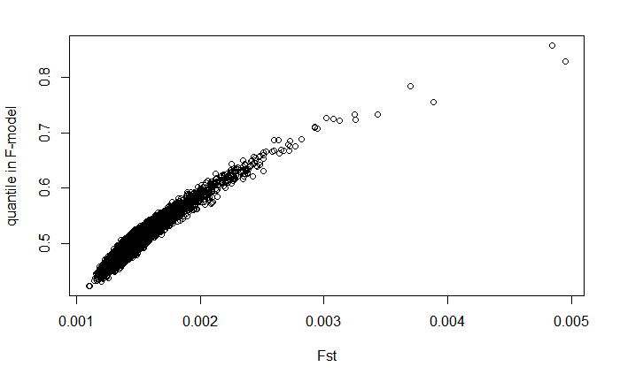

### Comparison of Hudson’s $F_{ST}$ estimate (fixed effect statistic) to the estimate of $F_{ST}$ from F-model (random effect parameter) and their differences:

When the Hudson’s $F_{ST}$ and F-Model $F_{ST}$ were plotted, it was observed that both were correlated even though they were on different scales.

Since Bayesian $F_{ST}$ is not constrained as we obtain it by multiplying the likelihood $(P(X_{ij}|p_{ij},n_{ij}))$ and the prior $(P(p_i|\pi_i,\theta_i))$ and the estimate is a compromise between the likelihood and the prior, the scales differ.

Therefore, the Hudson’s $F_{ST}$ and F-Model $F_{ST}$ **agree in terms of ranking but not on scales.**

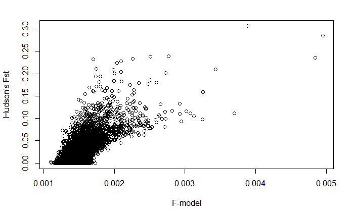

## Analysis of data from three focal scaffolds that were presented in the research paper:

The re-sequencing data for the analysis are for 10 individuals each of blue-winged and golden-winged warblers.

```r
#### -------------------------------------------------------
#### add a few scaffolds from WG resequencing    -----------
inds<-read.table("reseq_inds.txt", comment.char="")
inds<-as.numeric(inds[,-(1:9)])

# Re-sequencing data for "BWWA" and "GWWA"
reseq.ind.info<-read.csv("README.csv")
species<-reseq.ind.info$Species[reseq.ind.info$Species=="BWWA" |  reseq.ind.info$Species=="GWWA"]
```

### Scaffold 24:

We have found that there are **no improbable loci** given the scaffold-wide F-model from which Fst for individual loci are drawn beyond the 95% credible interval in scaffold 24.

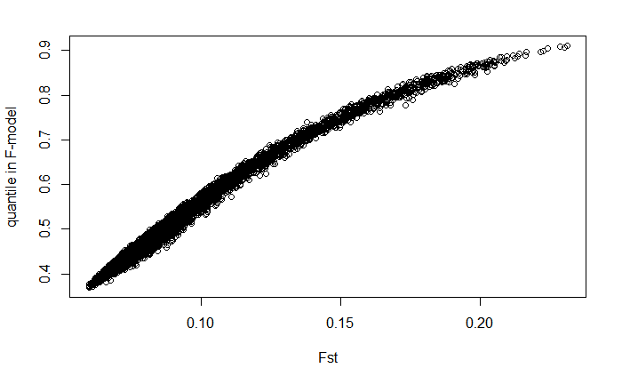

### Scaffold 120:

We have found that there are **no improbable loci** given the scaffold-wide F-model from which Fst for individual loci are drawn beyond the 95% credible interval in scaffold 120.

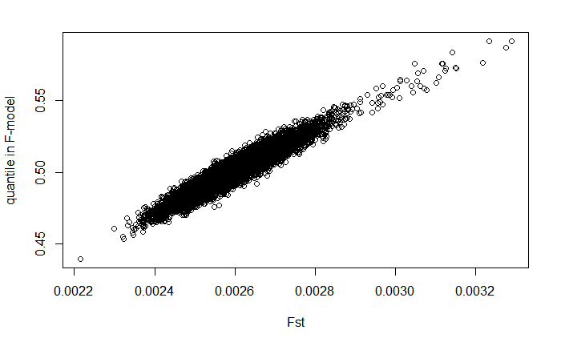

### Scaffold 299:

We have found that **there are loci that are improbable,** given the scaffold-wide F-model from which Fst for individual loci are drawn, beyond the 95% credible interval in scaffold 299. These values correspond to loci that are significantly different from the underlying model for FST[i] (the beta distribution with $\psi$ and S).

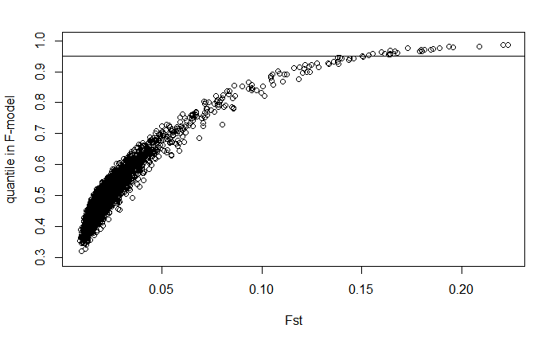